# Assignment 2: Hand Gesture Recognition [50 Pt]

### Part (iii) “Overfit” to a Small Dataset - [1pt MODEL]

One way to sanity check our neural network model and training code is to check whether the model is capable of “overfitting” or “memorizing” a small dataset. A properly constructed CNN with correct training code should be able to memorize the answers to a small number of images quickly.

Construct a small dataset (e.g. just the images that you have collected). Then show that your model and training code is capable of memorizing the labels of this small data set.

With a large batch size (e.g. the entire small dataset) and learning rate that is not too high, you should be able to obtain a 100% training accuracy on that small dataset relatively quickly (within 200 iterations).

```
Train size: 1947
Val size: 240
Test size: 240
CUDA is available!  Training on GPU ...
epoch: 0, Training Accuracy: 0.11328527291452112, Training Loss: 0.00112842080773117, Validation Accuracy: 0.1375
epoch: 1, Training Accuracy: 0.17816683831101957, Training Loss: 0.0011141131214441615, Validation Accuracy: 0.3375
epoch: 2, Training Accuracy: 0.3367662203913491, Training Loss: 0.001073306685664682, Validation Accuracy: 0.4583333333333333
epoch: 3, Training Accuracy: 0.4788877445932029, Training Loss: 0.000989872550866392, Validation Accuracy: 0.5125
epoch: 4, Training Accuracy: 0.5262615859938208, Training Loss: 0.0008680984553889121, Validation Accuracy: 0.5083333333333333
epoch: 5, Training Accuracy: 0.5463439752832132, Training Loss: 0.000757289594053671, Validation Accuracy: 0.5958333333333333
epoch: 6, Training Accuracy: 0.5550978372811535, Training Loss: 0.0006964349354850247, Validation Accuracy: 0.5625
epoch: 7, Training Accuracy: 0.582389289392379, Training Loss: 0.0006909011631178501, Validation Accuracy: 0.5875
epoch: 8, Training Accuracy: 0.607621009268795, Training Loss: 0.000657182200235407, Validation Accuracy: 0.6666666666666666
epoch: 9, Training Accuracy: 0.619979402677652, Training Loss: 0.0006300665870592052, Validation Accuracy: 0.6625
epoch: 10, Training Accuracy: 0.6611740473738414, Training Loss: 0.0005937640827376841, Validation Accuracy: 0.6916666666666667
epoch: 11, Training Accuracy: 0.668898043254377, Training Loss: 0.0005621831724444107, Validation Accuracy: 0.7375
epoch: 12, Training Accuracy: 0.685890834191555, Training Loss: 0.0005297447757103777, Validation Accuracy: 0.7458333333333333
epoch: 13, Training Accuracy: 0.6864057672502575, Training Loss: 0.0005151301576470374, Validation Accuracy: 0.7208333333333333
epoch: 14, Training Accuracy: 0.713697219361483, Training Loss: 0.0004992446167137173, Validation Accuracy: 0.7208333333333333
epoch: 15, Training Accuracy: 0.698249227600412, Training Loss: 0.0004923835006443488, Validation Accuracy: 0.725
epoch: 16, Training Accuracy: 0.7070030895983522, Training Loss: 0.0004845917928996427, Validation Accuracy: 0.7625
epoch: 17, Training Accuracy: 0.733264675592173, Training Loss: 0.00047155108033049455, Validation Accuracy: 0.7583333333333333
epoch: 18, Training Accuracy: 0.7270854788877446, Training Loss: 0.00046763508272097546, Validation Accuracy: 0.775
epoch: 19, Training Accuracy: 0.7368692070030896, Training Loss: 0.0004514423344890828, Validation Accuracy: 0.725
epoch: 20, Training Accuracy: 0.7378990731204943, Training Loss: 0.00044558136415408093, Validation Accuracy: 0.7416666666666667
epoch: 21, Training Accuracy: 0.7456230690010298, Training Loss: 0.0004368223590488365, Validation Accuracy: 0.7541666666666667
epoch: 22, Training Accuracy: 0.7543769309989702, Training Loss: 0.0004239604298004323, Validation Accuracy: 0.7458333333333333
epoch: 23, Training Accuracy: 0.7605561277033985, Training Loss: 0.00041898241640667946, Validation Accuracy: 0.7208333333333333
epoch: 24, Training Accuracy: 0.7631307929969104, Training Loss: 0.0004140670077887693, Validation Accuracy: 0.7166666666666667
epoch: 25, Training Accuracy: 0.7260556127703398, Training Loss: 0.0004390202305778578, Validation Accuracy: 0.6541666666666667
epoch: 26, Training Accuracy: 0.7188465499485067, Training Loss: 0.00045665947057433047, Validation Accuracy: 0.6958333333333333
epoch: 27, Training Accuracy: 0.7677651905252317, Training Loss: 0.0004066829198926427, Validation Accuracy: 0.7375
epoch: 28, Training Accuracy: 0.737384140061792, Training Loss: 0.000417233339994457, Validation Accuracy: 0.725
epoch: 29, Training Accuracy: 0.766735324407827, Training Loss: 0.0003955667607895705, Validation Accuracy: 0.7291666666666666
epoch: 30, Training Accuracy: 0.7796086508753862, Training Loss: 0.00037999865209131773, Validation Accuracy: 0.7125
epoch: 31, Training Accuracy: 0.7713697219361483, Training Loss: 0.00038840535609123336, Validation Accuracy: 0.7416666666666667
epoch: 32, Training Accuracy: 0.7883625128733265, Training Loss: 0.0003663384736839416, Validation Accuracy: 0.7583333333333333
epoch: 33, Training Accuracy: 0.782183316168898, Training Loss: 0.00036003550444741584, Validation Accuracy: 0.7375
epoch: 34, Training Accuracy: 0.7698249227600412, Training Loss: 0.0003653756459064219, Validation Accuracy: 0.75
epoch: 35, Training Accuracy: 0.7893923789907312, Training Loss: 0.00034651669956318955, Validation Accuracy: 0.7541666666666667
```

[output cut: 109 more lines]

```
epoch: 145, Training Accuracy: 0.9979402677651905, Training Loss: 1.8346522808932133e-05, Validation Accuracy: 0.7333333333333333
epoch: 146, Training Accuracy: 0.9979402677651905, Training Loss: 1.7368552788257843e-05, Validation Accuracy: 0.7291666666666666
epoch: 147, Training Accuracy: 0.9979402677651905, Training Loss: 1.6810396388670575e-05, Validation Accuracy: 0.7333333333333333
epoch: 148, Training Accuracy: 0.9979402677651905, Training Loss: 1.6089800494600088e-05, Validation Accuracy: 0.7333333333333333
epoch: 149, Training Accuracy: 0.9979402677651905, Training Loss: 1.5276626257573144e-05, Validation Accuracy: 0.7333333333333333
epoch: 150, Training Accuracy: 0.9984552008238929, Training Loss: 1.4553548749985913e-05, Validation Accuracy: 0.7333333333333333
epoch: 151, Training Accuracy: 0.9984552008238929, Training Loss: 1.4032694043780083e-05, Validation Accuracy: 0.7333333333333333
epoch: 152, Training Accuracy: 0.9989701338825953, Training Loss: 1.3425189506168786e-05, Validation Accuracy: 0.7333333333333333
epoch: 153, Training Accuracy: 0.9994850669412977, Training Loss: 1.2728487513098402e-05, Validation Accuracy: 0.7333333333333333
epoch: 154, Training Accuracy: 0.9994850669412977, Training Loss: 1.2222258445845546e-05, Validation Accuracy: 0.7333333333333333
epoch: 155, Training Accuracy: 0.9989701338825953, Training Loss: 1.1769657678094715e-05, Validation Accuracy: 0.7333333333333333
epoch: 156, Training Accuracy: 0.9994850669412977, Training Loss: 1.125454971529486e-05, Validation Accuracy: 0.7333333333333333
epoch: 157, Training Accuracy: 0.9994850669412977, Training Loss: 1.0725642680264646e-05, Validation Accuracy: 0.7333333333333333
epoch: 158, Training Accuracy: 1.0, Training Loss: 1.026853788921511e-05, Validation Accuracy: 0.7333333333333333
Overfitting achieved!
```

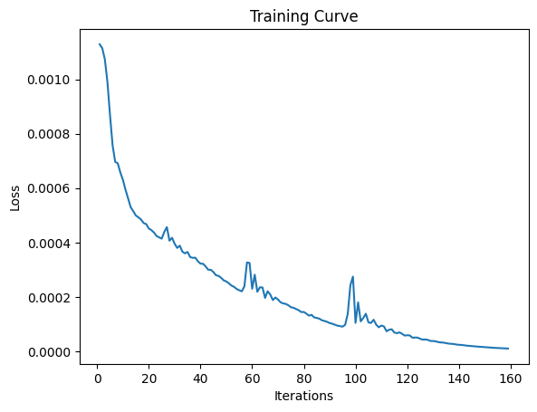

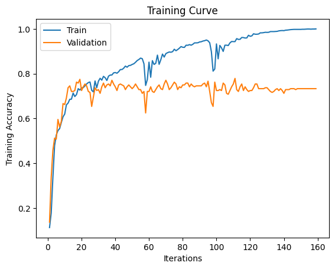

```
Final Training Accuracy: 1.0
Final Validation Accuracy: 0.7333333333333333
Highest Validation Accuracy:  0.7791666666666667
```

```python
# TO BE COMPLETED
batch_size = 1947
val_split = 0.1
test_split = 0.1
lr = 0.005

train_loader, val_loader, test_loader, classes = get_data_loader(dataset_root, batch_size, val_split, test_split)

model = CNN()
use_cuda = True

if use_cuda and torch.cuda.is_available():
  model.cuda()
  print('CUDA is available!  Training on GPU ...')
else:
  print('CUDA is not available.  Training on CPU ...')

#proper model
train(model, train_loader, val_loader, lr = lr, training_batch_size = batch_size, num_epochs=200)
```